# Reproducible Research

Jasper Slingsby

## The Reproducibility Crisis

> *“**Replication** is the ultimate standard by which scientific claims are judged.”* [@Peng2011]
- Replication is one of the fundamental tenets of science
- Findings from studies that cannot be independently replicated should be treated with caution!

## The Reproducibility Crisis

Sadly, we have a problem…

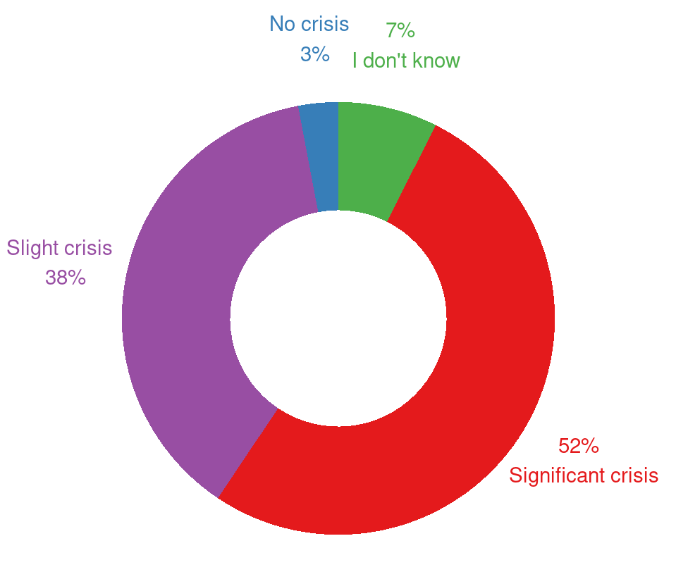

“‘Is there a reproducibility crisis?’  
A survey of >1500 top scientists [@Baker2016; @Penny2016].

## Reproducible Research

- Makes use of modern software tools to share data, code, etc to allow others to reproduce the same result as the original study, thus **making all analyses open and transparent**.
- This is *central to scientific progress!!!*
- BONUS: working reproducibly *facilitates automated workflows* needed for iterative ecological forecasting!

### Replication and the Reproducibility Spectrum

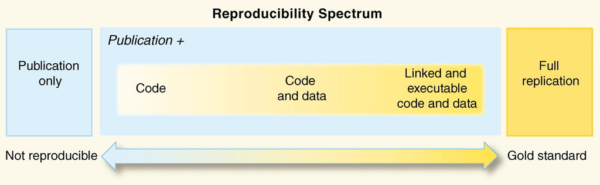

- **Full replication is a huge challenge** (and sometimes impossible)
- **Some studies may not be entirely replicable** (e.g. rare phenomena, long term records, very expensive projects like space missions).
- Where the “gold standard” of full replication cannot be achieved, we have to settle for a lower rung on **The Reproducibility Spectrum** [@Peng2011]

## Replication vs Reproducibility

- **Reproducibility** falls short of full **replication** because it focuses on reproducing the same result *from the same data set*, rather than analyzing independently collected data.
- This difference may seem trivial, but you’d be surprised at how few studies are even reproducible, let alone replicable.

## Reproducible Scientific Workflows

[figure not shown]

‘Data Pipeline’ from xkcd.com/2054, used under a [CC-BY-NC 2.5 license](https://creativecommons.org/licenses/by-nc/2.5/).

Working reproducibly requires careful planning and documentation of each step in your scientific workflow from *planning* your data collection to *sharing* your results.

## Reproducible Scientific Workflows

This entails overlapping/intertwined components, namely:

1. Data management (more on this in a later lecture)
2. File and folder management
3. Coding and code management (data manipulation and analyses)
4. Computing environment and software
5. Sharing of the data, metadata, code, publications and any other relevant materials

## 2. File and folder management

Project files and folders can get unwieldy fast and really bog you down!

The main considerations are:

- defining a simple, common, intuitive folder structure
- using informative file names
- version control

### Folders

Most projects have similar requirements

Here’s how I usually manage my folders:

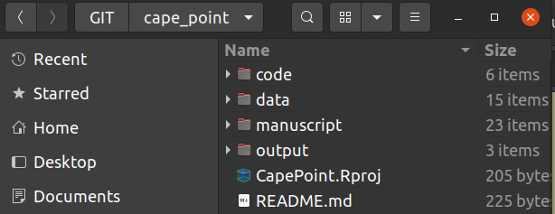

- “code”contains code for analyses
- “data” often has separate “raw” and “processed” (or “clean”) folders
  - Large files may be stored elsewhere
- “output” contains figures and tables

### Names should be

- machine readable
  - avoid spaces and funny punctuation
  - support searching and splitting, e.g. “data_raw.csv”, “data_clean.csv” can be searched by keywords and split into fields by “_”
- human readable
  - contents self evident from the name
- support sorting
  - numeric or character prefixes separate files by component or step
  - folder structure helps here too

## 3. Coding and code management

### Why write code?

“Point-and-click” software like Excel, Statistica, etc may seem easier, but you’ll regret it in the long run…

### Coding rules

Coding is communication. Messy code is bad communication, hampering collaboration and making it easier to make mistakes…

### Version control

[Streamline, collaborate, reuse, contribute, and fail safely…](https://www.openscapes.org/blog/2022/05/27/github-illustrated-series/)

## Why write code?

- **Automation** - reusing code is one click, and you’re unlikely to introduce errors
- A script provides a **record of your analysis**
- Scientific coding languages like Python or R allow you to **run almost any kind of analysis in one scripted workflow**
  - GIS, phylogenetics, multivariate or Bayesian statistics, etc
  - saves you manually exporting and importing data between softwares
- Most coding languages are **open source** (e.g. R, Python, JavaScript, etc)
  - You can share your code other users don’t have to pay
  - Transparency - Lots of people have checked the background code and functions you’re using, not just the software company
  - A culture of sharing code (online forums, with publications, etc)

## Some coding rules

It’seasytowritemessyindecipherablecode! *Write code for people, not computers!!!*

Check out the [Tidyverse style guide](https://style.tidyverse.org/index.html) for R-specific guidance, but here are some basics:

- use consistent, meaningful and distinct **names** for variables and functions
- use consistent code and **formatting style**
- **modularize code** into manageable steps/chunks
  - or separate scripts that can be called in order from a master script or Makefile
- use **commenting** to explain what you’re doing at each step or in each function
  - “notebooks” like RMarkdown or Jupyter Notebooks are handy for fulfilling roles like documentation, master/Makefiles, etc and can be developed into manuscripts
- write **functions** rather than repeating the same code
- **check for mistakes** at every step!!! Do the outputs make sense?

## Some coding rules continued…

- start with a “recipe”
  - outline the steps/modules before you start coding to keep you on track
  - e.g. a common recipe in R (using commented headers):

```r
#Header indicating purpose, author, date, version etc

#Define settings and load required libraries

#Read in data

#Wrangle/reformat/clean/summarize data as required

#Run analyses (often multiple steps)

#Wrangle/reformat/summarize analysis outputs for visualization

#Visualize outputs as figures or tables
```

- avoid proprietary formats! i.e. use open source scripting languages and file formats
- use version control!!!

## Version control

Version control tools can be challenging , but also hugely simplify your workflow!

I’ve only ever used Git and [GitHub](https://github.com/), but they all have similar functions. Technical terms from GitHub appear like `this`. You can look them up [here](https://docs.github.com/en/get-started/quickstart).

The advantages of version control as I see them:

- They generally help project management, especially **collaborations**
- They allow **easy code sharing** with collaborators or the public at large - through `repositories` (“repos”) or `gists` (code snippets)
- Users can easily **adapt or build on each others’ code** by `forking` repos and working on their own `branch`.
  - This allows you to **repeat/replicate analyses** or even build websites (like this one!)
- The **system is online**, but you **can also work offline** by `cloning` the repo to your local machine. You can `push` to or `pull` from the online repo to keep local and online versions updated.

## Version control continued…

- **Changes are tracked and reversible** through `commits`
  - Changes in the contents of a repo you must by `commit`ed with a `commit message` before pushing to the online repo. Each `commit` is a recoverable `version` that can be `compared` or `reverted` to
  - This is **the essence of version control** and magically frees you from duplicated files!
- Collaborators can **propose changes** via `pull requests`
  - Repo `owners` can **accept and integrate changes seamlessly** by `review` and `merge` the *forked branch* back to the `main` branch
  - Comments associated with `commit` or `pull request`s provide a **written record of changes** and track the user, date, time, etc - all of which and are useful tracking mistakes and `blaming` when things go wrong
- You can `assign`, log and track `issues` and `feature requests`

This should make more sense after the practical…

## 4. Computing environment

Sharing your code and data is not enough to maintain reproducibility…

**Software and hardware change with upgrades, versions or user community preferences**

- You’ll all know MicroSoft Excel, but have you heard of Quattro Pro or Lotus that were the preferred spreadsheet software of yesteryear?

The *simple solution* is to **carefully document the hardware and versions of software** used so that others can recreate that computing environment if needed.

## 4. Computing environment cont.

### Containers

A *better solution* is to use **containers** like [docker](https://www.docker.com/) or [singularity](https://sylabs.io/singularity/).

These are contained, lightweight computing environments similar to [virtual machines](https://en.wikipedia.org/wiki/Virtual_machine), that you can package with your software/workflow.

You set your container up to have everything you need to run your workflow (and nothing extra), so anyone can download (or clone) your container, code and data and run your analyses perfectly first time.

## 5. Sharing data, code, publication etc

This is covered in more detail in the data management lecture, but suffice to say there’s no point working reproducibly if you’re not going to share all the components necessary to complete your workflow…

Another key component here is that ideally all your data, code, publication etc are shared *Open Access* - i.e. they are not stuck behind some paywall…

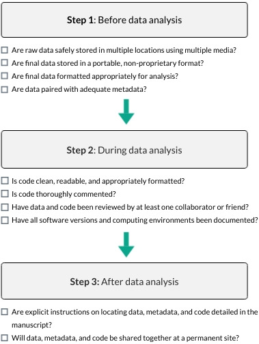

A 3-step, 10-point checklist to guide researchers toward greater reproducibility in their research [@Alston2021].

## Why work reproducibly?

[figure not shown]

Let’s start being more specific about our miracles… Cartoon © Sidney Harris. Used with permission ScienceCartoonsPlus.com

## Why work reproducibly?

> “*Five selfish reasons to work reproducibly*” [@Markowetz2015]
1. Its *transparent and open*, helping us avoid mistakes or track down errors in analyses
2. It makes it *easier to write papers*
3. It *helps the review process*
4. It *enables continuity* of the research
5. It helps to build your *reputation*

## Why work reproducibly?

Some less selfish reasons (and relevant for ecoforecasting):

6. It *speeds progress in science* by allowing you (or others) to rapidly build on previous findings and analyses
7. It *allows easy comparison* of new analytical approaches to older ones
8. It makes it easy to *repeat analyses on new data*, e.g. for ecological forecasting or LTER
9. The tools used are *useful beyond Reproducible Research*, e.g. building websites
10. Reproducible research *skills are highly sought after!*
- Skills are important should you decide to leave science…
- Within science, more and more environmental organizations and NGOs are hiring data scientists or scientists with strong data and quantitative skills.

## Barriers to working reproducibly

(Adapted from “A Beginner’s Guide to Conducting Reproducible Research” [@Alston2021])

**1. Complexity**

- There’s a learning curve in getting to know and use the tools effectively.
- One is always tempted by the “easy option” of doing it the way you already know or using “user-friendly” proprietary software.

**2. Technological change**

- Hardware and software used in analyses change over time, making it very difficult to rerun old analyses etc.
- This should be less of a problem as more tools lik contained computing environments become available

## Barriers to working reproducibly

**3. Human error**

- Simple mistakes or poor documentation can easily make a study irreproducible.
- Most reproducible research tools are actually aimed at solving this problem!

**4. Intellectual property rights**

- Rational self-interest can lead to hesitation to share data and code via many pathways:
  - Fear of not getting credit; Concern that the materials shared will be used incorrectly or unethically; etc
- Hopefully most of these issues will be solved by better awareness of licensing issues, attribution, etc, as the culture of reproducible research grows